# BMIProjPresentation

S Zaki

10/8/2018

## BMI Predictor

Body Mass Index (BMI) can be used to calcualte tissue mass of an individual which in turn can be used to categorize the individuals health status as Underweight, Normal Weight, Overweight or Obese.

In general the formula for calcualting BMI is:

```
       BMI = Weight/(Height)^2
```

BMI formula when using metric units: Weight in kgs and Height in cms.

[output not shown]

## Basics of App

This BMI Prediction App uses the dataset https://www.kaggle.com/yersever/500-person-gender-height-weight-bodymassindex. This data is used to Predict the BMI of the user based on the Weight and Gender selected by the user. The BMI value is then used to categorize the individual into one of the four categories namely Underweight, Normal Weight, Overweight or Obese.

The Dataset

```
## # A tibble: 6 x 5
##   Gender Height Weight Index   BMI
##   <fct>   <int>  <int> <int> <dbl>
## 1 Male      174     96     4  31.7
## 2 Male      189     87     2  24.4
## 3 Female    185    110     4  32.1
## 4 Female    195    104     3  27.4
## 5 Male      149     61     3  27.5
## 6 Male      189    104     3  29.1
```

## How it Works

This BMI Predictor App is a Shiny App. The User Interface has a Side Bar and Main Panel

### Side Bar

- displays instructions on how to use the App.
- displays options to select Gender (Female/Male).
- has a slider for selecting Weight.
- has a textbox input for Height.

### Main Panel

- displays a plot with the BMI vs weight of a sample of Females and Males (grey points), the predicted BMI for the user (red point for Female/blue point for Male) and the fitted regression line.
- displays predicted BMI of user and predicts their health status based on the BMI value (Underweight, Normal Weight,Overweight, Obese), reports Gender, Weight and Height of the user (red for Female/blue for Male).

## Plot Predicting BMI based on Weight and Gender

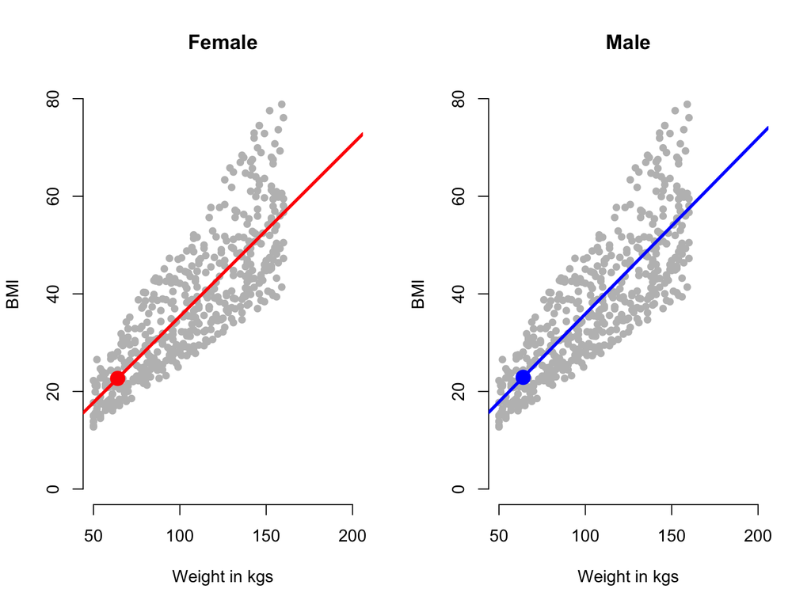